# DS-520 Data Analysis and Decision Model

## FINAL PROJECT

### Presented By

- Mir Ahmed, DS-520 WEB-NM-21FATR
- Joel Baruch, DS-520 PHYB4-21FATR
- Nilanjana Chatterjee, DS-520 PHYB4-21FATR
- Weiwan Zhao, DS-520 PHYB4-21

#### 1) Introduction

#### 2) Executive Summary

#### 3) Part 1: Data Collection

#### 4) Part 2: Exploratory Data Analysis

#### 5) Part 3: Hypothesis Testing

#### 6) Part 4: Linear Regression Model and Anova

# Introduction

A mutual fund is a company that pools money from many investors and invests the money in securities such as stocks, bonds, and short-term debt. The combined holdings of the mutual fund are known as its portfolio. The level of risk in a mutual fund depends on what it invests in. Usually, the higher the potential returns, the higher the risk will be. For example, stocks are generally riskier than bonds, so an equity fund tends to be riskier than a fixed income fund.

Some specialty mutual funds focus on certain kinds of investments, such as emerging markets, to try to earn a higher return. These kinds of funds also tend to have a greater risk of a larger drop in value. Given the general belief among people that mutual funds tend to be risker and are not safe to invest. Following is your null hypothesis.

H0 : Null Hypothesis: Mutual funds are risky and does not give much returns.

Average rate of return (µ) <= ~2 %

Alternate Hypothesis you are trying to prove if Mutual funds are safe to invest.

Ha : Alternate Hypothesis : Mutual funds are safe and give good returns.

Average rate of return (µ) > 2%

# Executive Summary

We collected our datasets from gthe following URLs using web scraping:

1. Funds' Overview: https://fundresearch.fidelity.com/fund-screener/results/table/overview/averageAnnualReturnsYear3/desc/
2. Funds' Risks: https://fundresearch.fidelity.com/fund-screener/results/table/risk/averageAnnualReturnsYear3/desc/
3. Funds' Yields: https://fundresearch.fidelity.com/fund-screener/results/table/daily-pricing-yields/averageAnnualReturnsYear3/desc/

After collecting the datasets, we cleaned them and merged them to create our final dataset which is used for exploratory analysis, hypothesis testing, linear regression model and ANOVA regression analysis.

Through hypthesis testing, we found that the mutual funds' returns in USA are way above 2% in general (rejecting uor null hypothesis).

We were able to create a linear regression model which gave 94.45% accuracy level for prediction.

# Part 1: Collect Your Dataset

For this part, we chose to collect our data from https://fundresearch.fidelity.com/fund-screener/, which has data on 9626 funds - the comprehensive set of Mutual Funds in the USA.

We collected the data in 2 phases:

First we collected scraped the for overview and risk sepearately.

Then we cleaned and merged them to create our final dataset.

```python
#dependencies and setup
import pandas as pd
import requests
from bs4 import BeautifulSoup
from splinter import Browser
from webdriver_manager.chrome import ChromeDriverManager
import time
import numpy as np
import matplotlib.pyplot as plt
from sklearn.metrics import r2_score
import seaborn as sns
import scipy.stats as stats
import statsmodels.api as sm
```

```python
# create a browser instance using splinter
executable_path = {'executable_path': ChromeDriverManager().install()}
browser = Browser('chrome', **executable_path, headless=False)
time.sleep(1)
```

### Scraping overview data

```python
# Empty lists
names = []
ms_cat = []
ytd_daily = []
yr1 = []
yr3= []
yr5 = []
yr10 = []
life_of_fund = []
net_expense_ratio = []
gross_expense_ratio = []
ms_rating_overall = []

for i in range(1,98):
    # visit fidelity URL
    fidelity_url = f"https://fundresearch.fidelity.com/fund-screener/results/\
    table/overview/averageAnnualReturnsYear3/desc/{i}?assetClass=&category=&order=assetClass%2Ccategory"
    browser.visit(fidelity_url)
    time.sleep(4)

    # create HTML object
    html = browser.html

    # parse HTML with BeautifulSoup
    soup = BeautifulSoup(html, 'html.parser')

    div = soup.find('div', id ='static-table-container')
    table = div.find('table', id = 'static-table')
    tbody = table.find('tbody', id = 'static-tbody')
    for listing in tbody.find_all('td', class_ = 'name left'):
        for name in listing.find_all('a'):
            names.append(name.text)
    div2 = soup.find('div', id ='scrollable-results-table-wrapper')
    table2 = div2.find('table', id = 'scrollable-results-table')
    tbody2 = table2.find('tbody', id = 'results-tbody')
    for listing in tbody2.find_all('td', class_ = 'morningstarCategory left'):
            ms_cat.append(listing.text)
    for listing in tbody2.find_all('td', class_ = 'ytdDaily right'):
            ytd_daily.append(listing.text)
    for listing in tbody2.find_all('td', class_ = 'yr1 left'):
            yr1.append(listing.text)
    for listing in tbody2.find_all('td', class_ = 'yr3 left sorted-column-cell'):
            yr3.append(listing.text)
    for listing in tbody2.find_all('td', class_ = 'yr5 left'):
            yr5.append(listing.text)
    for listing in tbody2.find_all('td', class_ = 'yr10 left'):
            yr10.append(listing.text)
    for listing in tbody2.find_all('td', class_ = 'lifeOfFund left'):
            life_of_fund.append(listing.text)
    for listing in tbody2.find_all('td', class_ = 'netExpenseRatio right'):
            net_expense_ratio.append(listing.text)
    for listing in tbody2.find_all('td', class_ = 'grossExpenseRatio right'):
            gross_expense_ratio.append(listing.text)
    for listing in tbody2.find_all('td', class_ = 'morningstarRatingOverall center'):
            if type(listing.find('span')) == type(None):
                    ms_rating_overall.append("")
            else:
                    ms_rating_overall.append(listing.find('span').text)
    print(f"{len(names)} funds scraped until page {i}")
```

```python
# creating overview dataframe
df_overview = pd.DataFrame({'name' : names, 'morningstar_category': ms_cat, 'ytdDaily': ytd_daily, 'yr1': yr1,\
                            'yr3': yr3, 'yr5': yr5, 'yr10': yr10, 'life_of_fund': life_of_fund,\
                            'net_expense_ratio': net_expense_ratio, 'gross_expense_ratio': gross_expense_ratio,\
                            'morningstar_rating_overall': ms_rating_overall})
```

```python
# cleaning overview dataframe
for col in df_overview.columns[2:-1]:
    df_overview[f"{col}"] = df_overview[f"{col}"].str.replace('%', '', regex=True)
    df_overview[f"{col}"] = df_overview[f"{col}"].str.replace('+', '', regex=True)
    df_overview[f"{col}"] = pd.to_numeric(df_overview[f"{col}"], errors='coerce')
```

### Scraping risk data

```python
names = []
categories = []
risks = []
stds = []
srs = []
betas = []
r2s = []

for i in range(1,98):
    fidelity_url = f"https://fundresearch.fidelity.com/fund-screener/results/\
    table/risk/averageAnnualReturnsYear3/desc/{i}?assetClass=&category=&order=assetClass%2Ccategory"
    browser.visit(fidelity_url)
    time.sleep(4)

    # create HTML object
    html = browser.html

    # parse HTML with BeautifulSoup
    soup = BeautifulSoup(html, 'html.parser')

    div = soup.find('div', id ='static-table-container')
    table = div.find('table', id = 'static-table')
    tbody = table.find('tbody', id = 'static-tbody')
    for listing in tbody.find_all('td', class_ = 'name left'):
        for name in listing.find_all('a'):
            names.append(name.text)

    div2 = soup.find('div', id ='scrollable-results-table-wrapper')
    table2 = div2.find('table', id = 'scrollable-results-table')
    tbody2 = table2.find('tbody', id = 'results-tbody')
    for listing in tbody2.find_all('td', class_ = "morningstarCategory left"):
        category = listing.find('span').text
        categories.append(category)
    for listing in tbody2.find_all('td', class_ = "morningstarCategoryRisk center"):
        risk = listing.find('div', class_ = "risk-icon-gradient")
        risks.append(risk.get("class", "")[2][-1])
    for listing in tbody2.find_all('td', class_ = "standardDeviation right"):
        if type(listing.find('span')) == type(None):
            stds.append("")
        else:
            stds.append(listing.find('span').text)
    for listing in tbody2.find_all('td', class_ = "sharpeRatio3Yr right"):
        if type(listing.find('span')) == type(None):
            srs.append("")
        else:
            srs.append(listing.find('span').text)
    for listing in tbody2.find_all('td', class_ = "beta right"):
        if type(listing.find('span')) == type(None):
            betas.append("")
        else:
            betas.append(listing.find('span').text)
    for listing in tbody2.find_all('td', class_ = "r2 right"):
        if type(listing.find('span')) == type(None):
            r2s.append("")
        else:
            r2s.append(listing.find('span').text)
    print(f"{len(names)} funds scraped until page {i}")
```

```python
# creating risk dataframe
df_risk = pd.DataFrame({'name' : names, 'morningstar_category': categories, 'risk': risks, 'std_dev': stds,\
                            'sharpe_ratio_3_yr': srs, 'beta': betas, 'r2': r2s})
```

### Scraping yield data

```python
names = []
morningstar_category = []
nav_dollar_amount = []
nav_change_dollar_amount = []
nav_change_pct = []
daily_30_day_yield = []
daily_7_day_yield = []
minimum_investment = []
last_dividend = []
morningstar_rating_overall = []

for i in range(1,98):
    fidelity_url = f"https://fundresearch.fidelity.com/fund-screener/results/\
    table/daily-pricing-yields/averageAnnualReturnsYear3/desc/{i}?assetClass=&category=&order=assetClass%2Ccategory"
    browser.visit(fidelity_url)
    time.sleep(4)

    # create HTML object
    html = browser.html

    # parse HTML with BeautifulSoup
    soup = BeautifulSoup(html, 'html.parser')

    div = soup.find('div', id ='static-table-container')
    table = div.find('table', id = 'static-table')
    tbody = table.find('tbody', id = 'static-tbody')
    for listing in tbody.find_all('td', class_ = 'name left'):
        for name in listing.find_all('a'):
            names.append(name.text)

    div2 = soup.find('div', id ='scrollable-results-table-wrapper')
    table2 = div2.find('table', id = 'scrollable-results-table')
    tbody2 = table2.find('tbody', id = 'results-tbody')
    for listing in tbody2.find_all('td', class_ = "morningstarCategory left"):
        if type(listing.find('span')) == type(None):
            morningstar_category.append("")
        else:
            morningstar_category.append(listing.find('span').text)
    for listing in tbody2.find_all('td', class_ = "navDollarAmount right"):
        if type(listing.find('span')) == type(None):
            nav_dollar_amount.append("")
        else:
            nav_dollar_amount.append(listing.find('span').text)
    for listing in tbody2.find_all('td', class_ = "navChangeDollarAmount right"):
        if type(listing.find('span')) == type(None):
            nav_change_dollar_amount.append("")
        else:
            nav_change_dollar_amount.append(listing.find('span').text)
    for listing in tbody2.find_all('td', class_ = "navChangePct right"):
        if type(listing.find('span')) == type(None):
            nav_change_pct.append("")
        else:
            nav_change_pct.append(listing.find('span').text)
    for listing in tbody2.find_all('td', class_ = "daily30DayYield right"):
        if type(listing.find('span')) == type(None):
            daily_30_day_yield.append("")
        else:
            daily_30_day_yield.append(listing.find('span').text)
    for listing in tbody2.find_all('td', class_ = "daily7DayYield right"):
        if type(listing.find('span')) == type(None):
            daily_7_day_yield.append("")
        else:
            daily_7_day_yield.append(listing.find('span').text)
    for listing in tbody2.find_all('td', class_ = "minimumInvestment right"):
        if type(listing.find('span')) == type(None):
            minimum_investment.append("")
        else:
            minimum_investment.append(listing.find('span').text)
    for listing in tbody2.find_all('td', class_ = "lastDividend right"):
        if type(listing.find('span')) == type(None):
            last_dividend.append("")
        else:
            last_dividend.append(listing.find('span').text)
    for listing in tbody2.find_all('td', class_ = "morningstarRatingOverall center"):
        if type(listing.find('span')) == type(None):
            morningstar_rating_overall.append("")
        else:
            morningstar_rating_overall.append(listing.find('span').text)
    print(f"{len(names)} funds scraped until page {i}")
```

```python
# creating yield dataframe
df_yield = pd.DataFrame({'name' : names, 'morningstar_category': morningstar_category, 'nav_dollar_amount': nav_dollar_amount,\
                           'nav_change_dollar_amount': nav_change_dollar_amount, 'daily_30_day_yield': daily_30_day_yield,\
                           'daily_7_day_yield': daily_7_day_yield, 'minimum_investment': minimum_investment,\
                           'last_dividend':last_dividend, 'morningstar_rating_overall': morningstar_rating_overall})
```

```python
# cleaning yield dataframe
df_yield.drop(columns=['morningstar_category','nav_dollar_amount', 'nav_change_dollar_amount'\
                       , 'daily_30_day_yield', 'daily_7_day_yield', 'morningstar_rating_overall'], inplace = True)
for col in df_yield.columns[1:]:
    df_yield[f"{col}"] = df_yield[f"{col}"].str.replace('$', '', regex=True)
    df_yield[f"{col}"] = df_yield[f"{col}"].str.replace(',', '', regex=True)
    df_yield[f"{col}"] = pd.to_numeric(df_yield[f"{col}"], errors='coerce')
```

```python
# close the browser session
browser.quit()
```

### Merging the dataframes

```python
# merging overview with risk
df = pd.merge(df_overview, df_risk, on = "name", how = "left")
del df['morningstar_category_y']
df.rename(columns={"morningstar_category_x": "morningstar_category"}, inplace = True)
```

```python
# merging yield
df = pd.merge(df, df_yield, on = "name", how = "left")
```

```python
# Exporting the dataframe into a csv file
df.to_csv('fidelity_mutual_funds_return_w_risk.csv', index = False)
```

# Part 2: Exploratory Data Analysis

## Understanding the data

```python
fidelity_df = pd.read_csv('fidelity_mutual_funds_return_w_risk.csv')
fidelity_df.head()
```

|  | name | morningstar_category | ytdDaily | yr1 | yr3 | yr5 | yr10 | life_of_fund | net_expense_ratio | gross_expense_ratio | morningstar_rating_overall | risk | std_dev | sharpe_ratio_3_yr | beta | r2 | minimum_investment | last_dividend |
| --- | --- | --- | --- | --- | --- | --- | --- | --- | --- | --- | --- | --- | --- | --- | --- | --- | --- | --- |
| 0 | Baron Partners Fund Institutional Shares (BPTIX) | Large Growth | 44.60 | 110.27 | 65.56 | 47.54 | 29.02 | 27.02 | 1.30 | 1.30 | 1137.0 | 6 | 40.41 | 1.60 | 1.51 | 0.63 | 1000000.0 | 0.2224 |
| 1 | Baron Partners Fund Retail Shares (BPTRX) | Large Growth | 44.28 | 109.72 | 65.13 | 47.15 | 28.68 | 20.45 | 1.56 | 1.56 | 1137.0 | 6 | 40.39 | 1.59 | 1.51 | 0.63 | 2500.0 | 0.1243 |
| 2 | Morgan Stanley Institutional Fund, Inc. Incept... | Small Growth | 20.05 | 81.15 | 55.11 | 38.37 | 22.37 | 14.14 | 1.00 | 1.19 | 574.0 | 7 | 40.44 | 1.34 | 1.40 | 0.71 | 5000000.0 | 0.0000 |
| 3 | Morgan Stanley Institutional Fund, Inc. Incept... | Small Growth | 19.75 | 80.67 | 54.70 | 37.98 | 22.01 | 13.83 | 1.35 | 1.45 | 574.0 | 7 | 40.48 | 1.32 | 1.40 | 0.71 | 2500.0 | 0.0000 |
| 4 | Morgan Stanley Institutional Fund, Inc. Incept... | Small Growth | NaN | 79.39 | 53.46 | 36.90 | 21.11 | 13.00 | 2.10 | 2.27 | 574.0 | 7 | 40.42 | 1.30 | 1.40 | 0.71 | 2500.0 | NaN |

```python
# counting unique values
unique_fund_names = len(pd.unique(fidelity_df['name']))
total_fund_names = len(fidelity_df)

print(f'there are {unique_fund_names} \
      funds in this data set of {total_fund_names} funds')
```

```
there are 9626       funds in this data set of 9626 funds
```

We can see that there are no duplicate samples in the dataset. Let's further explore the distributions and qualities of our data:

```python
fidelity_df.describe()
```

|  | ytdDaily | yr1 | yr3 | yr5 | yr10 | life_of_fund | net_expense_ratio | gross_expense_ratio | morningstar_rating_overall | risk | std_dev | sharpe_ratio_3_yr | beta | r2 | minimum_investment | last_dividend |
| --- | --- | --- | --- | --- | --- | --- | --- | --- | --- | --- | --- | --- | --- | --- | --- | --- |
| count | 9359.000000 | 9520.000000 | 9204.000000 | 8922.000000 | 7283.000000 | 9613.000000 | 9625.000000 | 9624.000000 | 9102.000000 | 9626.000000 | 9154.000000 | 9154.000000 | 8189.000000 | 8189.000000 | 9.624000e+03 | 9178.000000 |
| mean | 12.841688 | 25.532315 | 12.170789 | 9.872851 | 8.455235 | 7.796146 | 1.154081 | 1.412057 | 464.152604 | 5.271556 | 14.547154 | 0.784549 | 0.788115 | 0.805881 | 2.455934e+05 | 0.116582 |
| std | 12.137653 | 20.381654 | 8.276280 | 7.080595 | 5.485703 | 5.245337 | 0.570965 | 1.333127 | 362.456368 | 1.665109 | 8.134948 | 0.391578 | 1.218248 | 0.282312 | 8.381462e+05 | 0.499280 |
| min | -22.090000 | -37.660000 | -29.380000 | -23.430000 | -19.020000 | -11.740000 | 0.000000 | 0.000000 | 10.000000 | 0.000000 | 0.180000 | -2.450000 | -21.000000 | 0.000000 | 0.000000e+00 | 0.000000 |
| 25% | 1.890000 | 6.010000 | 5.460000 | 3.740000 | 3.760000 | 4.650000 | 0.760000 | 0.850000 | 186.000000 | 4.000000 | 7.192500 | 0.550000 | 0.820000 | 0.810000 | 2.500000e+03 | 0.013883 |
| 50% | 11.970000 | 26.135000 | 11.265000 | 9.120000 | 8.180000 | 7.080000 | 1.050000 | 1.190000 | 361.000000 | 6.000000 | 16.080000 | 0.780000 | 0.960000 | 0.930000 | 2.500000e+03 | 0.034480 |
| 75% | 22.070000 | 40.180000 | 16.950000 | 14.160000 | 12.530000 | 10.170000 | 1.490000 | 1.700000 | 631.000000 | 6.000000 | 19.870000 | 1.030000 | 1.050000 | 0.970000 | 5.000000e+03 | 0.118995 |
| max | 83.850000 | 146.460000 | 65.560000 | 47.540000 | 29.020000 | 82.450000 | 5.250000 | 46.990000 | 1250.000000 | 9.000000 | 59.740000 | 2.610000 | 8.750000 | 1.000000 | 1.000000e+07 | 24.012771 |

Seeing the description of the data, and focusing on the one, three, five and ten year returns, we do see that the means are always positive and above 7.7%. We also see that the standard deviation in each of our samplingn columns gets smaller over the years, which makes sense as funds' returns would "smoothe" over time, creating smaller and smaller deviations.

Beyond that, we do see that for each investment horizon (1, 3, 5, and 10 years) there are those funds that lose money, but we also see that they are a minority, as the 25th percentile is positive in all horizons.

Let's investigate further with some box plots:

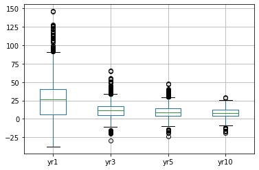

```python
fidelity_df.boxplot(['yr1', 'yr3', 'yr5', 'yr10'])
```

Again, seeing the bulk of the performances in the positive ranges. Also, we see how the `yr1` spread is wider and gets smaller and smaller for the following time horizons. Still, this clouds the visibility into the other horizons.

Let's break up the plots and customize the size and granularity of the grids:

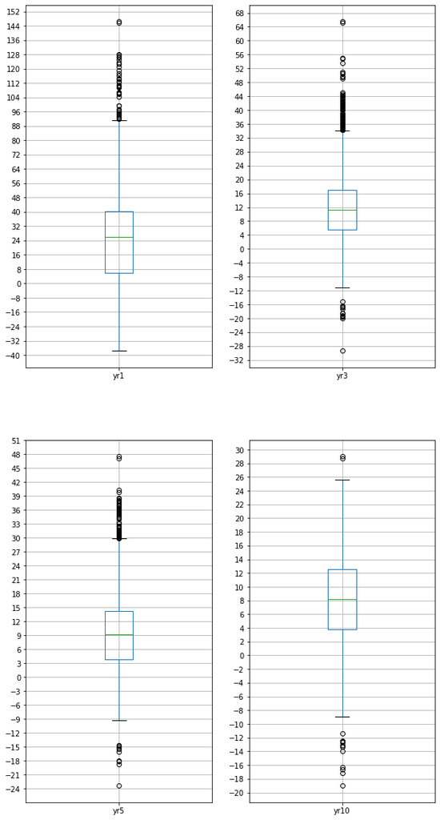

```python
fig, ax = plt.subplots(2,2, figsize=(10,20))

for idx, column in enumerate(fidelity_df.columns[3:7]):
    ax.flat[idx].yaxis.set_major_locator(plt.MaxNLocator(30))
    fidelity_df.boxplot([column], ax=ax.flatten()[idx])
```

Still, we see that the bulk of the measurments for all time horizons is safely above the 2% mark. We're begining to be optimistic about the average performance of an arbitrary mutual fund.

Furhter, something we'd like to point out and visualize, is how the average return does trend down over the time horizons:

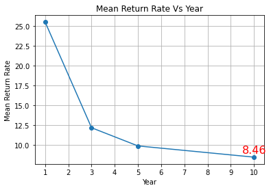

```python
year = [1,3,5,10]
mean_return = [fidelity_df['yr1'].mean(), fidelity_df['yr3'].mean() ,
               fidelity_df['yr5'].mean(), fidelity_df['yr10'].mean()]

plt.plot(year, mean_return, marker = 'o')
plt.grid(zorder=0)
plt.title('Mean Return Rate Vs Year')
plt.xlabel('Year')
plt.ylabel('Mean Return Rate')
plt.xticks(np.arange(min(year), max(year)+1, 1.0))
plt.annotate(round(min(mean_return),2),
             (max(year)-.5, min(mean_return)+.5),fontsize=16,color="red")
plt.show()
```

In the above plot, we do see how the average return trends down over time, though it might be asymptotical, and still stay at a positive and acceptable level.

Let us now further explore the distribution of values:

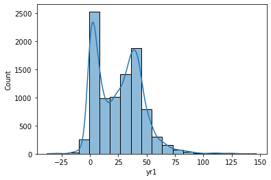

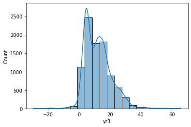

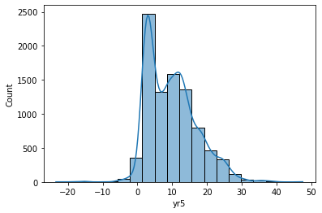

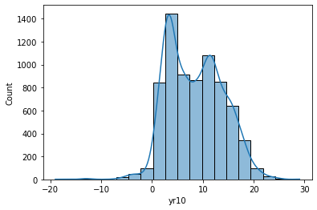

```python
for column in fidelity_df.columns[3:7]:
    sns.histplot(fidelity_df[column], kde=True, bins=20)
    plt.show()
```

Looking at the distribution of returns, we see most of the mass towards the center, with some skew in some of the horizons. We can also see that the left and right edges of the histograms contain some minimal frequencies. These graphs may approximate normal curves, but not perfectly, as there is visible skew and lowered center values in some cases.

Let's now take a look at the distribution of funds over the Morningstar categories to better understand the market of mutual funds.

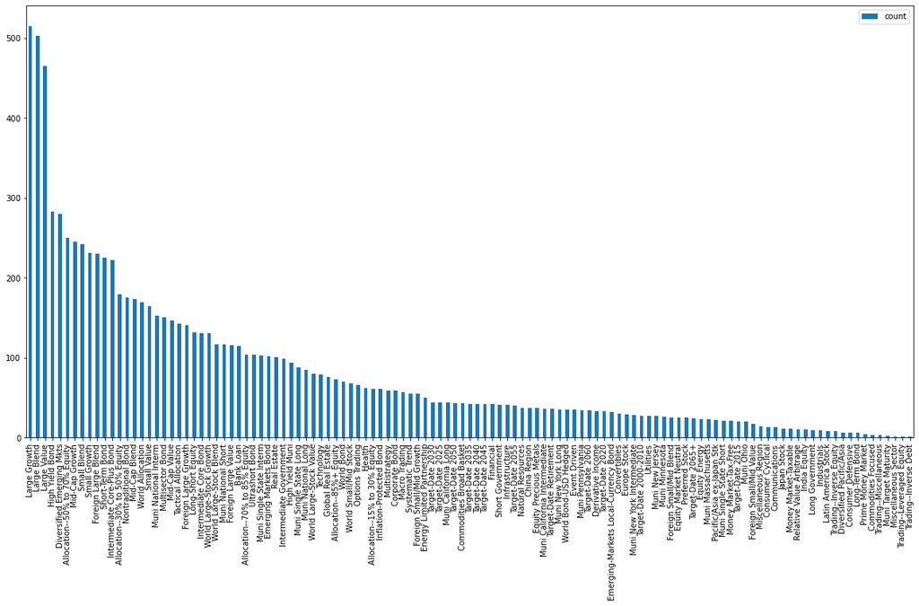

```python
from collections import Counter

# Unique categories
fidelity_df['morningstar_category'].nunique()

cat_cnt = Counter(fidelity_df['morningstar_category'])
cat_cnt_fidelity_df=pd.DataFrame.from_dict(cat_cnt, orient='index', columns = ['count'])
cat_cnt_fidelity_df.sort_values('count', ascending= False, inplace=True)
cat_cnt_fidelity_df.plot(kind='bar', figsize = (20,10))
```

```python
len(pd.unique(fidelity_df['morningstar_category']))
```

```
119
```

Exploring the above, we can see that there's a main market focus on the 'Large Growth', 'Large Blend', and 'Large Value' with a long tail of the other 116 categories.

# Part 3: Hypothesis Testing

We see that there's a large enough number to perform statistical hypothesis testing. We'll, therefore, perform 4 tests at once, all having the same null and alternative hypothesis, but over the different investment horizons:

- H0: average return <= 2%
- Ha: average return > 2%

For the 1-year, 3-year, 5-year, and 10-year horizon.

To start, let's explore how the "meta" average behaves considering the data's `stdev` as a standard error by dividing by the √n of the size of the samples. In other words, how does the measured mean behave or distribute considering the standard error of the data:

```python
from math import *
import scipy.stats as st

stats_df = fidelity_df.describe().drop(['ytdDaily', 'life_of_fund', \
                                        'net_expense_ratio', 'gross_expense_ratio', \
                                        'morningstar_rating_overall', 'risk', 'std_dev'\
                                       ,'sharpe_ratio_3_yr', 'beta', 'r2', 'minimum_investment'\
                                       , 'last_dividend'], axis=1)
stats_df = stats_df.drop(['min', '25%', '50%', '75%', 'max'])
stats_df
```

|  | yr1 | yr3 | yr5 | yr10 |
| --- | --- | --- | --- | --- |
| count | 9520.000000 | 9204.000000 | 8922.000000 | 7283.000000 |
| mean | 25.532315 | 12.170789 | 9.872851 | 8.455235 |
| std | 20.381654 | 8.276280 | 7.080595 | 5.485703 |

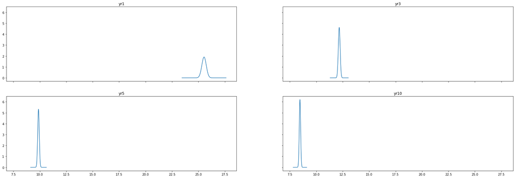

```python
fig, ax = plt.subplots(2,2, sharex=True, sharey=True, figsize=(30,10))

for idx, col in enumerate(stats_df.columns):
    count = stats_df.loc['count'][col]
    mean = stats_df.loc['mean'][col]
    std = stats_df.loc['std'][col]
    std_err = std/sqrt(count)

    x = np.linspace(mean - 10*std_err, mean + 10*std_err, 1000)
    ax.flatten()[idx].plot(x, st.norm.pdf(x, mean, std_err))
    ax.flatten()[idx].title.set_text(col)
```

Now we're able to see the distribution of the average expected return itself for each horizon. Seeing how they all remain absolutely distant from the 2% mark, we're getting a pretty good indication that the `Ha` or `alternative hypothesis` from the next part will clearly be accepted.

> Not knowing the standard deviation in the wild, we'll perform a T-test on the data.

> We randomly stratify the data into 5 groups, and perform 5x4=20 T tests on the data.

```python
stratified_df = {}
for i in range(5):
    stratified_df[i] = fidelity_df[fidelity_df.columns[3:7]].sample(frac=0.2)
    print(f'Random sample test #{i+1}')
    print(stratified_df[i].apply(
        lambda period_sample:
        st.ttest_1samp(period_sample.dropna(), 2, alternative='greater' )) \
          .rename({0:'T Statistic', 1:'P Value'}))
    print()
```

```
Random sample test #1
                   yr1        yr3            yr5           yr10
T Statistic  51.240158  53.389997   4.736050e+01   4.559708e+01
P Value       0.000000   0.000000  2.081228e-317  1.368278e-282

Random sample test #2
                   yr1        yr3            yr5           yr10
T Statistic  49.568869  51.996934   4.696277e+01   4.627493e+01
P Value       0.000000   0.000000  1.000833e-314  7.718880e-289

Random sample test #3
                   yr1        yr3            yr5           yr10
T Statistic  51.469627  53.424833   4.771945e+01   4.566700e+01
P Value       0.000000   0.000000  1.225283e-321  9.157987e-283

Random sample test #4
                   yr1        yr3            yr5           yr10
T Statistic  50.668846  53.173947   4.748732e+01   4.566009e+01
P Value       0.000000   0.000000  5.072078e-320  2.829554e-284

Random sample test #5
                   yr1        yr3            yr5           yr10
T Statistic  49.173508  51.399747   4.615293e+01   4.387022e+01
P Value       0.000000   0.000000  4.162747e-307  1.959979e-268
```

# Conclusion

Seeing these minimal P-Values for our one-sample, one-sided T-Tests, we're able to reject the null hypothesis on all time periods, thus safely assuming that mutual funds will have an average return of more than 2% on any of the 1-year, 3-year, 5-year, and 10-year investment horizons.

# Part 4 Bonus: Regression Analysis / ANOVA Analysis (extra 20 points)

We will submit this part in a separate document.

# Function for forward select linear model

```python
import statsmodels.formula.api as smf

def forward_selected(data, response):
    """Linear model designed by forward selection.

    Parameters:
    -----------
    data : pandas DataFrame with all possible predictors and response

    response: string, name of response column in data

    Returns:
    --------
    model: an "optimal" fitted statsmodels linear model
           with an intercept
           selected by forward selection
           evaluated by adjusted R-squared
    """
    remaining = set(data.columns)
    remaining.remove(response)
    selected = []
    current_score, best_new_score = 0.0, 0.0
    while remaining and current_score == best_new_score:
        scores_with_candidates = []
        for candidate in remaining:
            formula = "{} ~ {}".format(response,
                                           ' + '.join(selected + [candidate]))
            score = smf.ols(formula, data).fit().rsquared_adj
            scores_with_candidates.append((score, candidate))
        scores_with_candidates.sort()
        best_new_score, best_candidate = scores_with_candidates.pop()
        if current_score < best_new_score:
            remaining.remove(best_candidate)
            selected.append(best_candidate)
            current_score = best_new_score
    formula = "{} ~ {}".format(response,
                                   ' + '.join(selected))
    model = smf.ols(formula, data).fit()
    return model
```

```python
# Importing the csv
df= pd.read_csv('fidelity_mutual_funds_return_w_risk.csv')
df.head()
```

|  | name | morningstar_category | ytdDaily | yr1 | yr3 | yr5 | yr10 | life_of_fund | net_expense_ratio | gross_expense_ratio | morningstar_rating_overall | risk | std_dev | sharpe_ratio_3_yr | beta | r2 | minimum_investment | last_dividend |
| --- | --- | --- | --- | --- | --- | --- | --- | --- | --- | --- | --- | --- | --- | --- | --- | --- | --- | --- |
| 0 | Baron Partners Fund Institutional Shares (BPTIX) | Large Growth | 44.60 | 110.27 | 65.56 | 47.54 | 29.02 | 27.02 | 1.30 | 1.30 | 1137.0 | 6 | 40.41 | 1.60 | 1.51 | 0.63 | 1000000.0 | 0.2224 |
| 1 | Baron Partners Fund Retail Shares (BPTRX) | Large Growth | 44.28 | 109.72 | 65.13 | 47.15 | 28.68 | 20.45 | 1.56 | 1.56 | 1137.0 | 6 | 40.39 | 1.59 | 1.51 | 0.63 | 2500.0 | 0.1243 |
| 2 | Morgan Stanley Institutional Fund, Inc. Incept... | Small Growth | 20.05 | 81.15 | 55.11 | 38.37 | 22.37 | 14.14 | 1.00 | 1.19 | 574.0 | 7 | 40.44 | 1.34 | 1.40 | 0.71 | 5000000.0 | 0.0000 |
| 3 | Morgan Stanley Institutional Fund, Inc. Incept... | Small Growth | 19.75 | 80.67 | 54.70 | 37.98 | 22.01 | 13.83 | 1.35 | 1.45 | 574.0 | 7 | 40.48 | 1.32 | 1.40 | 0.71 | 2500.0 | 0.0000 |
| 4 | Morgan Stanley Institutional Fund, Inc. Incept... | Small Growth | NaN | 79.39 | 53.46 | 36.90 | 21.11 | 13.00 | 2.10 | 2.27 | 574.0 | 7 | 40.42 | 1.30 | 1.40 | 0.71 | 2500.0 | NaN |

```python
df.columns
```

```
Index(['name', 'morningstar_category', 'ytdDaily', 'yr1', 'yr3', 'yr5', 'yr10',
       'life_of_fund', 'net_expense_ratio', 'gross_expense_ratio',
       'morningstar_rating_overall', 'risk', 'std_dev', 'sharpe_ratio_3_yr',
       'beta', 'r2', 'minimum_investment', 'last_dividend'],
      dtype='object')
```

# Feature selection

```python
# Extracting all the numeric columns
df_num = df[['ytdDaily', 'yr1', 'yr3', 'yr5', 'yr10',
       'life_of_fund', 'net_expense_ratio', 'gross_expense_ratio',
       'morningstar_rating_overall', 'risk', 'std_dev', 'sharpe_ratio_3_yr',
       'beta', 'r2', 'minimum_investment', 'last_dividend']].dropna()
df_num
```

|  | ytdDaily | yr1 | yr3 | yr5 | yr10 | life_of_fund | net_expense_ratio | gross_expense_ratio | morningstar_rating_overall | risk | std_dev | sharpe_ratio_3_yr | beta | r2 | minimum_investment | last_dividend |
| --- | --- | --- | --- | --- | --- | --- | --- | --- | --- | --- | --- | --- | --- | --- | --- | --- |
| 0 | 44.60 | 110.27 | 65.56 | 47.54 | 29.02 | 27.02 | 1.30 | 1.30 | 1137.0 | 6 | 40.41 | 1.60 | 1.51 | 0.63 | 1000000.0 | 0.222400 |
| 1 | 44.28 | 109.72 | 65.13 | 47.15 | 28.68 | 20.45 | 1.56 | 1.56 | 1137.0 | 6 | 40.39 | 1.59 | 1.51 | 0.63 | 2500.0 | 0.124300 |
| 2 | 20.05 | 81.15 | 55.11 | 38.37 | 22.37 | 14.14 | 1.00 | 1.19 | 574.0 | 7 | 40.44 | 1.34 | 1.40 | 0.71 | 5000000.0 | 0.000000 |
| 3 | 19.75 | 80.67 | 54.70 | 37.98 | 22.01 | 13.83 | 1.35 | 1.45 | 574.0 | 7 | 40.48 | 1.32 | 1.40 | 0.71 | 2500.0 | 0.000000 |
| 5 | 29.85 | 78.53 | 51.07 | 37.87 | 21.75 | 21.12 | 1.07 | 1.07 | 550.0 | 6 | 33.96 | 1.47 | 1.16 | 0.62 | 1000000.0 | 0.002900 |
| ... | ... | ... | ... | ... | ... | ... | ... | ... | ... | ... | ... | ... | ... | ... | ... | ... |
| 9190 | 50.49 | 112.78 | -11.17 | -9.38 | -4.58 | -1.65 | 1.35 | 1.87 | 72.0 | 8 | 48.41 | -0.25 | 1.12 | 0.95 | 2500.0 | 0.112000 |
| 9192 | 37.18 | 106.34 | -16.52 | -14.67 | -12.41 | -3.39 | 1.42 | 1.42 | 72.0 | 8 | 56.46 | -0.31 | 2.44 | 0.64 | 2500.0 | 1.837037 |
| 9193 | 36.87 | 105.81 | -16.69 | -14.87 | -12.72 | -3.74 | 1.68 | 1.68 | 72.0 | 8 | 56.42 | -0.31 | 2.44 | 0.64 | 2500.0 | 1.837037 |
| 9194 | 36.89 | 105.82 | -16.74 | -14.88 | -12.62 | -3.63 | 1.68 | 1.68 | 72.0 | 8 | 56.44 | -0.32 | 2.44 | 0.64 | 2500.0 | 1.837037 |
| 9195 | 36.04 | 104.30 | -17.35 | -15.51 | -13.28 | -4.34 | 2.43 | 2.43 | 72.0 | 8 | 56.40 | -0.33 | 2.44 | 0.64 | 2500.0 | 1.837037 |

6203 rows × 16 columns

# Linear regression model

```python
model = forward_selected(df_num.dropna(), 'yr10')
print("Selected features for the model:")
print(model.model.formula)
print("----------------------------------")
print("Adjusted R squared for the model:")
print(model.rsquared_adj)
```

```
Selected features for the model:
yr10 ~ yr5 + yr3 + life_of_fund + ytdDaily + yr1 + r2 + gross_expense_ratio + morningstar_rating_overall + risk + sharpe_ratio_3_yr + std_dev + net_expense_ratio + minimum_investment
----------------------------------
Adjusted R squared for the model:
0.9444266011578509
```

```python
print(model.summary())
```

```
                            OLS Regression Results
==============================================================================
Dep. Variable:                   yr10   R-squared:                       0.945
Model:                            OLS   Adj. R-squared:                  0.944
Method:                 Least Squares   F-statistic:                     8109.
Date:                Sat, 20 Nov 2021   Prob (F-statistic):               0.00
Time:                        12:31:00   Log-Likelihood:                -10247.
No. Observations:                6203   AIC:                         2.052e+04
Df Residuals:                    6189   BIC:                         2.062e+04
Df Model:                          13
Covariance Type:            nonrobust
==============================================================================================
                                 coef    std err          t      P>|t|      [0.025      0.975]
----------------------------------------------------------------------------------------------
Intercept                      0.7433      0.105      7.070      0.000       0.537       0.949
yr5                            0.9030      0.011     83.411      0.000       0.882       0.924
yr3                           -0.2693      0.010    -27.497      0.000      -0.288      -0.250
life_of_fund                   0.2965      0.008     36.702      0.000       0.281       0.312
ytdDaily                       0.0836      0.005     15.369      0.000       0.073       0.094
yr1                           -0.0261      0.004     -6.132      0.000      -0.035      -0.018
r2                             0.7745      0.069     11.274      0.000       0.640       0.909
gross_expense_ratio           -0.2662      0.033     -8.118      0.000      -0.330      -0.202
morningstar_rating_overall     0.0003   5.25e-05      4.770      0.000       0.000       0.000
risk                          -0.0632      0.020     -3.179      0.001      -0.102      -0.024
sharpe_ratio_3_yr             -0.5183      0.079     -6.576      0.000      -0.673      -0.364
std_dev                       -0.0300      0.006     -4.701      0.000      -0.043      -0.017
net_expense_ratio              0.1494      0.048      3.093      0.002       0.055       0.244
minimum_investment         -3.352e-08   2.01e-08     -1.665      0.096    -7.3e-08    5.95e-09
==============================================================================
Omnibus:                     1135.566   Durbin-Watson:                   1.841
Prob(Omnibus):                  0.000   Jarque-Bera (JB):             8786.598
Skew:                          -0.662   Prob(JB):                         0.00
Kurtosis:                       8.678   Cond. No.                     6.40e+06
==============================================================================

Notes:
[1] Standard Errors assume that the covariance matrix of the errors is correctly specified.
[2] The condition number is large, 6.4e+06. This might indicate that there are
strong multicollinearity or other numerical problems.
```

# Correlation between the response and explanatory variables

```python
for col in df_num.columns.difference(['yr10', 'last_dividend', 'beta']):
    print(f"Correlation between yr10 and {col} is {stats.pearsonr(df_num['yr10'].values,df_num[col].values)[0]}")
```

```
Correlation between yr10 and gross_expense_ratio is -0.043466501612530156
Correlation between yr10 and life_of_fund is 0.8252743569158877
Correlation between yr10 and minimum_investment is 0.03846300222625589
Correlation between yr10 and morningstar_rating_overall is 0.5347603693302172
Correlation between yr10 and net_expense_ratio is 0.0037295280795975154
Correlation between yr10 and r2 is 0.3601893515895218
Correlation between yr10 and risk is 0.5510176060654153
Correlation between yr10 and sharpe_ratio_3_yr is 0.42204222818958054
Correlation between yr10 and std_dev is 0.5833578563997679
Correlation between yr10 and yr1 is 0.6612711971272358
Correlation between yr10 and yr3 is 0.8749152051615144
Correlation between yr10 and yr5 is 0.9461939495764184
Correlation between yr10 and ytdDaily is 0.6567130333247719
```

# Actual vs predicted plot

```python
X = df_num[df_num.columns.difference(['yr10', 'last_dividend', 'beta'])].dropna()
y = df_num['yr10'].dropna().values
predictions = model.predict(X).values
r2 = model.rsquared_adj
```

```python
correlation, p_value = stats.pearsonr(y,predictions)
print(f"Correlation between actual and predicted is {correlation}")
```

```
Correlation between actual and predicted is 0.9718760664044803
```

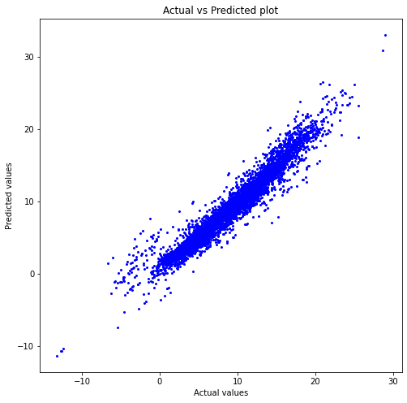

```python
plt.figure(figsize=(8,8))
plt.plot(y, predictions, 'o', color='blue', markersize=2)
plt.xlabel("Actual values")
plt.ylabel("Predicted values")
plt.title('Actual vs Predicted plot')
```

#### Our model's predictions are pretty close to actual values. Also our R-squared value is 94.5% which is pretty high.

## Model score

```python
from sklearn.linear_model import LinearRegression
lin_reg_model = LinearRegression()

lin_reg_model.fit(X, y)
print(f"Training Data Score: {lin_reg_model.score(X, y)}")
```

```
Training Data Score: 0.9445430884498451
```

# Model plot with one explanatory variable with the highest correlation

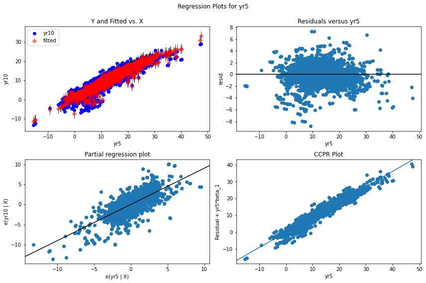

```python
#define figure size
fig = plt.figure(figsize=(12,8))

#produce regression plots
fig = sm.graphics.plot_regress_exog(model, 'yr5', fig=fig)
```

## Residual plot

```python
# Getting residual values
residuals = y - predictions
residuals
```

```
array([-4.01766782, -2.1700478 ,  0.06551326, ..., -2.0163843 ,
       -1.95942283, -1.89180646])
```

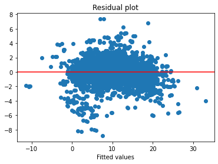

```python
plt.scatter(predictions, residuals)
plt.axhline(y = 0, color = 'r', linestyle = '-')
plt.xlabel("Fitted values")
plt.title('Residual plot')
```

## Normal Q-Q Plot

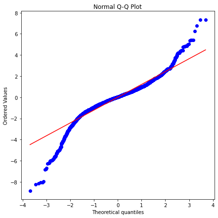

```python
# Plotting residual values on a normall Q-Q plot
plt.figure(figsize=(7,7))
stats.probplot(residuals, dist="norm", plot=plt)
plt.title("Normal Q-Q Plot")
```

# Anova of OLS (Ordinary least squared) model

```python
anova_table = sm.stats.anova_lm(model)
anova_table
```

|  | df | sum_sq | mean_sq | F | PR(>F) |
| --- | --- | --- | --- | --- | --- |
| yr5 | 1.0 | 159572.166398 | 159572.166398 | 99913.721691 | 0.000000e+00 |
| yr3 | 1.0 | 4072.959165 | 4072.959165 | 2550.222371 | 0.000000e+00 |
| life_of_fund | 1.0 | 3199.929739 | 3199.929739 | 2003.588073 | 0.000000e+00 |
| ytdDaily | 1.0 | 669.963411 | 669.963411 | 419.487554 | 2.934155e-90 |
| yr1 | 1.0 | 365.704202 | 365.704202 | 228.980208 | 8.004859e-51 |
| r2 | 1.0 | 188.684904 | 188.684904 | 118.142226 | 2.842844e-27 |
| gross_expense_ratio | 1.0 | 111.082308 | 111.082308 | 69.552523 | 9.083572e-17 |
| morningstar_rating_overall | 1.0 | 38.323975 | 38.323975 | 23.995983 | 9.899106e-07 |
| risk | 1.0 | 27.740343 | 27.740343 | 17.369200 | 3.119681e-05 |
| sharpe_ratio_3_yr | 1.0 | 50.175736 | 50.175736 | 31.416786 | 2.171539e-08 |
| std_dev | 1.0 | 32.363664 | 32.363664 | 20.264023 | 6.869318e-06 |
| net_expense_ratio | 1.0 | 18.596081 | 18.596081 | 11.643657 | 6.483453e-04 |
| minimum_investment | 1.0 | 4.427257 | 4.427257 | 2.772061 | 9.597322e-02 |
| Residual | 6189.0 | 9884.449514 | 1.597100 | NaN | NaN |

#### F critical value

```python
# At 5% level of significance
stats.f.ppf(q=1-.05, dfn=13, dfd=6189)
```

```
1.7217356615435946
```

# Anova for different years' rates

```python
stats.f_oneway(df_num['yr1'], df_num['yr3'], df_num['yr5'], df_num['yr10'])
```

```
F_onewayResult(statistic=2917.3689315577753, pvalue=0.0)
```

#### As the p-value is close to 0, we can say that the mean returns of each years are different